# 期末小组大作业代码

## 逗号数量

### EI

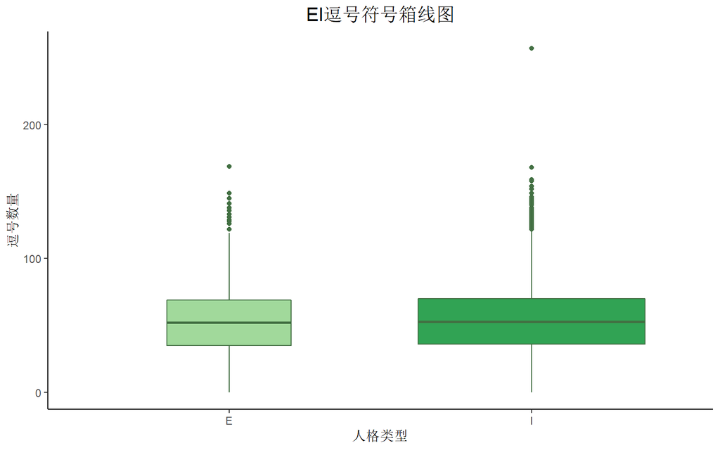

```r
p<-ggplot(data,aes(x=EI,y=douhao))
p+geom_boxplot(fill=c("#A1D99B","#31A354"),col="#426F42",varwidth=T)+scale_fill_brewer(palette="Greens")+labs(x="人格类型",y="逗号数量")+ theme_classic()+ggtitle("EI逗号符号箱线图")+mytheme
```

### NS

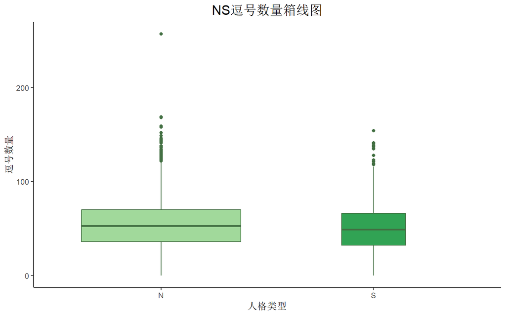

```r
p<-ggplot(data,aes(x=NS,y=douhao))
p+geom_boxplot(fill=c("#A1D99B","#31A354"),col="#426F42",varwidth=T)+scale_fill_brewer(palette="Greens")+labs(x="人格类型",y="逗号数量")+ theme_classic()+ggtitle("NS逗号数量箱线图")+mytheme
```

### FT

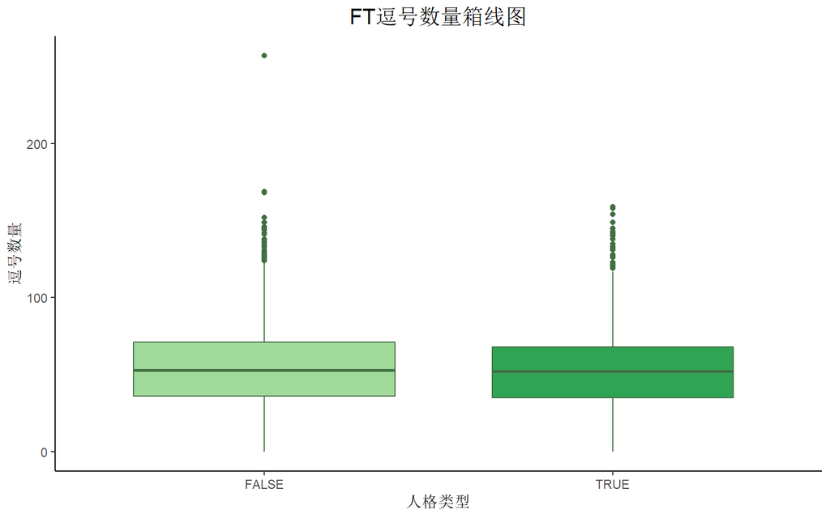

```r
p<-ggplot(data,aes(x=FT,y=douhao))
p+geom_boxplot(fill=c("#A1D99B","#31A354"),col="#426F42",varwidth=T)+scale_fill_brewer(palette="Greens")+labs(x="人格类型",y="逗号数量")+ theme_classic()+ggtitle("FT逗号数量箱线图")+mytheme
```

### JP

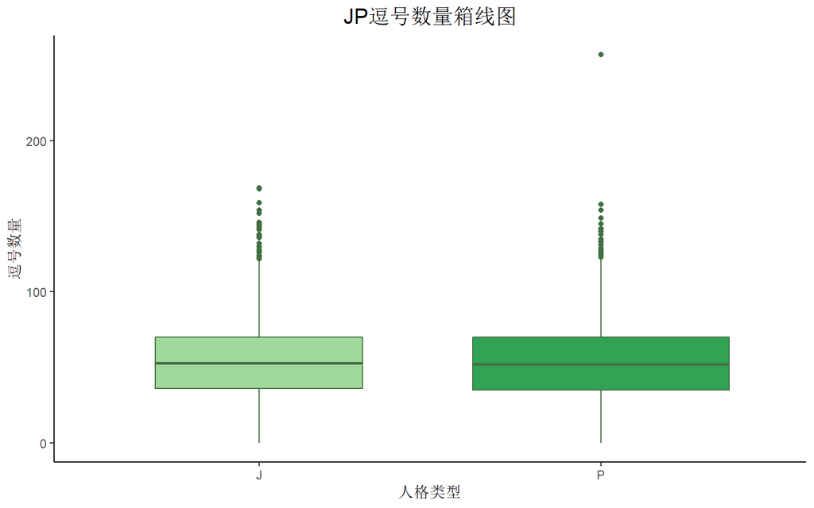

```r
p<-ggplot(data,aes(x=JP,y=douhao))
p+geom_boxplot(fill=c("#A1D99B","#31A354"),col="#426F42",varwidth=T)+scale_fill_brewer(palette="Greens")+labs(x="人格类型",y="逗号数量")+ theme_classic()+ggtitle("JP逗号数量箱线图")+mytheme
```

## 问号数量

### EI

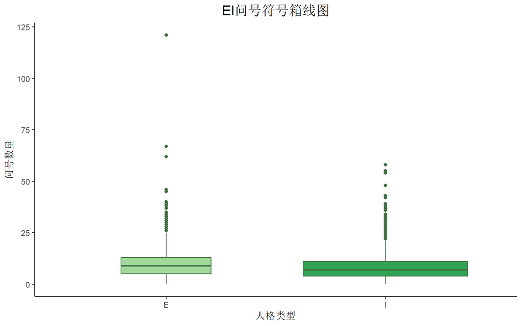

```r
p<-ggplot(data,aes(x=EI,y=wenhao))
p+geom_boxplot(fill=c("#A1D99B","#31A354"),col="#426F42",varwidth=T)+scale_fill_brewer(palette="Greens")+labs(x="人格类型",y="问号数量")+ theme_classic()+ggtitle("EI问号符号箱线图")+mytheme
```

### NS

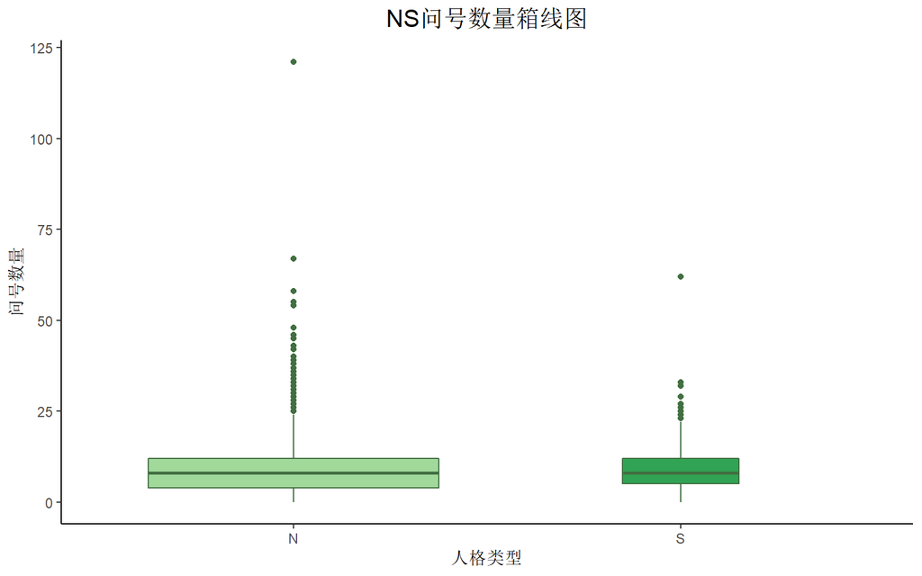

```r
p<-ggplot(data,aes(x=NS,y=wenhao))
p+geom_boxplot(fill=c("#A1D99B","#31A354"),col="#426F42",varwidth=T)+scale_fill_brewer(palette="Greens")+labs(x="人格类型",y="问号数量")+ theme_classic()+ggtitle("NS问号数量箱线图")+mytheme
```

### FT

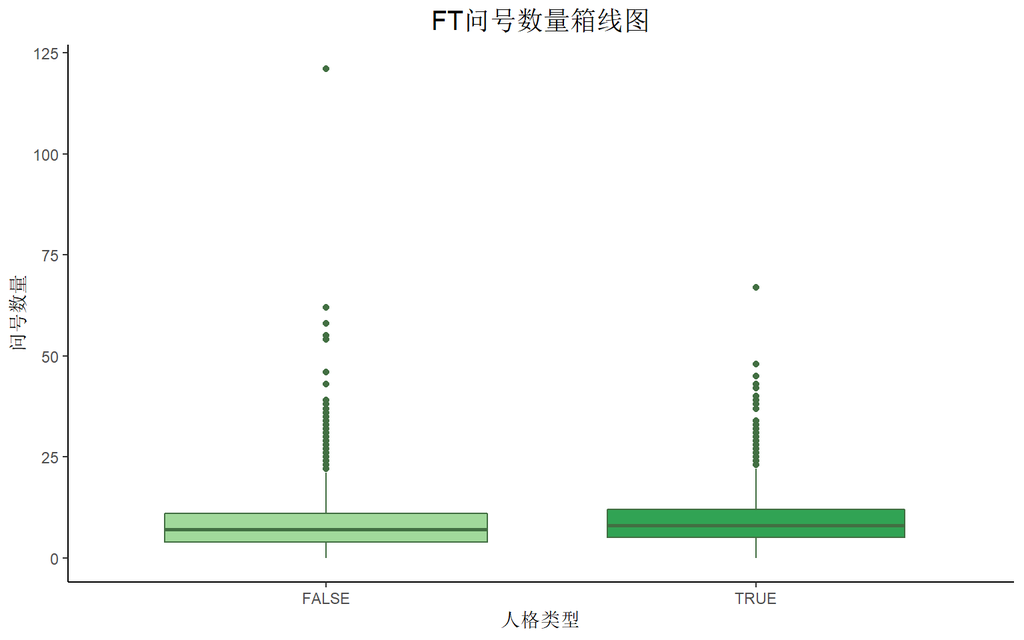

```r
p<-ggplot(data,aes(x=FT,y=wenhao))
p+geom_boxplot(fill=c("#A1D99B","#31A354"),col="#426F42",varwidth=T)+scale_fill_brewer(palette="Greens")+labs(x="人格类型",y="问号数量")+ theme_classic()+ggtitle("FT问号数量箱线图")+mytheme
```

### JP

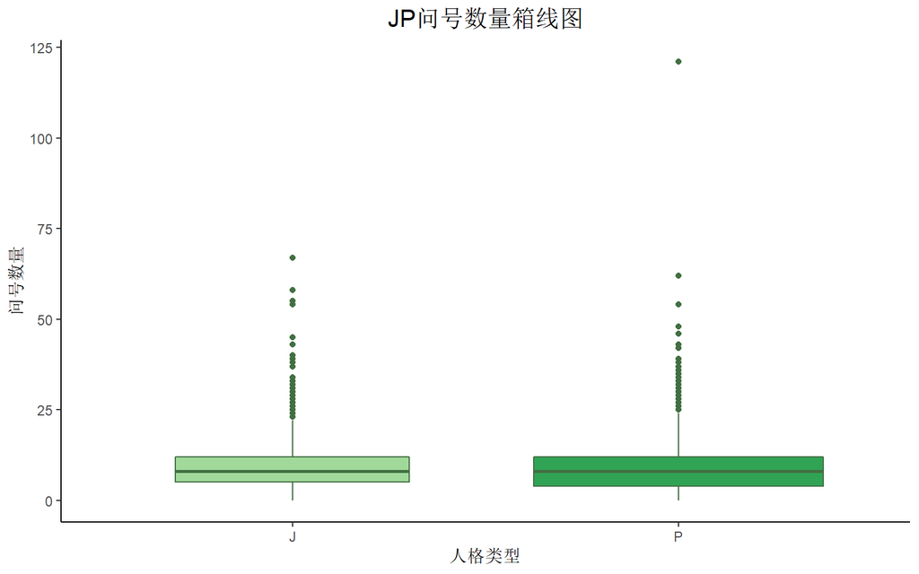

```r
p<-ggplot(data,aes(x=JP,y=wenhao))
p+geom_boxplot(fill=c("#A1D99B","#31A354"),col="#426F42",varwidth=T)+scale_fill_brewer(palette="Greens")+labs(x="人格类型",y="问号数量")+ theme_classic()+ggtitle("JP问号数量箱线图")+mytheme
```

# 建模准备

## 整理后变量读入

```r
#final为整理好的所有提取出来的变量的数据
dat <- read.csv("final.csv",stringsAsFactors = FALSE) #读入数据
dat = data.frame(dat)
summary(dat) #展示数据概要
```

```
##       EI                 NS                FT               JP
##  Length:8675        Length:8675        Mode :logical   Length:8675
##  Class :character   Class :character   FALSE:4694      Class :character
##  Mode  :character   Mode  :character   TRUE :3981      Mode  :character
##
##
##
##
##   motion_mean        motion_var      motion_range       num_http
##  Min.   :-8.5200   Min.   :  0.00   Min.   :  0.00   Min.   : 0.000
##  1st Qu.:-0.2428   1st Qu.: 18.60   1st Qu.: 21.00   1st Qu.: 0.000
##  Median : 0.5000   Median : 24.21   Median : 25.00   Median : 1.000
##  Mean   : 0.5403   Mean   : 25.62   Mean   : 25.51   Mean   : 3.305
##  3rd Qu.: 1.2600   3rd Qu.: 31.08   3rd Qu.: 29.00   3rd Qu.: 4.000
##  Max.   :12.1800   Max.   :303.60   Max.   :107.00   Max.   :91.000
##
##     senlengh         wenhao            judian          douhao
##  Min.   : 3.00   Min.   :  0.000   Min.   :  0.0   Min.   :  0.00
##  1st Qu.:23.15   1st Qu.:  5.000   1st Qu.:134.0   1st Qu.: 36.00
##  Median :27.26   Median :  8.000   Median :172.0   Median : 52.00
##  Mean   :26.48   Mean   :  8.715   Mean   :169.5   Mean   : 53.59
##  3rd Qu.:30.56   3rd Qu.: 12.000   3rd Qu.:206.0   3rd Qu.: 70.00
##  Max.   :39.97   Max.   :121.000   Max.   :748.0   Max.   :257.00
##
##      senvar              disE             disI             disN
##  Min.   :   4.143   Min.   :0.1912   Min.   :0.2140   Min.   :0.1836
##  1st Qu.: 103.628   1st Qu.:0.4378   1st Qu.:0.4635   1st Qu.:0.4385
##  Median : 136.574   Median :0.5023   Median :0.5262   Median :0.4969
##  Mean   : 132.980   Mean   :0.4994   Mean   :0.5237   Mean   :0.4937
##  3rd Qu.: 164.207   3rd Qu.:0.5620   3rd Qu.:0.5869   3rd Qu.:0.5543
##  Max.   :1583.927   Max.   :1.1277   Max.   :1.1422   Max.   :1.1075
##  NA's   :1
##       disS             disF             disT             disJ
##  Min.   :0.1721   Min.   :0.2226   Min.   :0.1854   Min.   :0.2290
##  1st Qu.:0.4077   1st Qu.:0.4754   1st Qu.:0.4400   1st Qu.:0.4561
##  Median :0.4656   Median :0.5344   Median :0.4970   Median :0.5139
##  Mean   :0.4637   Mean   :0.5351   Mean   :0.4960   Mean   :0.5108
##  3rd Qu.:0.5215   3rd Qu.:0.5944   3rd Qu.:0.5542   3rd Qu.:0.5689
##  Max.   :1.0721   Max.   :1.1170   Max.   :1.0876   Max.   :0.9925
##
##       disP
##  Min.   :0.1890
##  1st Qu.:0.4371
##  Median :0.4973
##  Mean   :0.4956
##  3rd Qu.:0.5549
##  Max.   :1.0206
##
```

```r
dat <- dat[-775,] #预处理数据(有零值)

#四个二分类
dat$EI <- factor(dat$EI) #EI人格
dat$NS <- factor(dat$NS) #NS人格
dat$FT <- factor(dat$FT) #FT人格
dat$JP <- factor(dat$JP) #JP人格
```

## 测试集和训练集划分

```r
#五折交叉验证
library(caret) #载入caret包
set.seed(2020) #设置随机数种子
index = createFolds(dat$EI, k = 5, list = FALSE, returnTrain = FALSE) #测试集和训练集划分的指标

testIndex = which(index == 1)
datTraincv = dat[-testIndex , ]     #训练集
datTestcv  = dat[testIndex , ]      #测试集
```

# 逻辑回归模型构建

## EI人格

### 全模型

```r
glm1 <- glm(EI ~ motion_mean + motion_var + motion_range + num_http + senlengh + judian + wenhao + douhao + senvar + disE + disI , data = dat, family=binomial(link="logit")) #全模型回归
summary(glm1) #全模型概要
```

```
##
## Call:
## glm(formula = EI ~ motion_mean + motion_var + motion_range +
##     num_http + senlengh + judian + wenhao + douhao + senvar +
##     disE + disI, family = binomial(link = "logit"), data = dat)
##
## Deviance Residuals:
##     Min       1Q   Median       3Q      Max
## -2.5413   0.4008   0.6154   0.7536   1.5465
##
## Coefficients:
##                Estimate Std. Error z value Pr(>|z|)
## (Intercept)   1.747e+00  2.662e-01   6.564 5.23e-11 ***
## motion_mean  -1.025e-01  2.173e-02  -4.716 2.40e-06 ***
## motion_var   -1.184e-02  4.359e-03  -2.716  0.00662 **
## motion_range  6.072e-03  7.199e-03   0.843  0.39898
## num_http      3.453e-02  6.319e-03   5.465 4.63e-08 ***
## senlengh      7.837e-03  8.353e-03   0.938  0.34809
## judian        9.265e-04  6.441e-04   1.438  0.15035
## wenhao       -2.999e-02  4.251e-03  -7.054 1.74e-12 ***
## douhao        3.914e-03  1.235e-03   3.169  0.00153 **
## senvar       -9.625e-04  6.041e-04  -1.593  0.11106
## disE          1.356e+01  9.477e-01  14.307  < 2e-16 ***
## disI         -1.398e+01  9.520e-01 -14.689  < 2e-16 ***
## ---
## Signif. codes:  0 '***' 0.001 '**' 0.01 '*' 0.05 '.' 0.1 ' ' 1
##
## (Dispersion parameter for binomial family taken to be 1)
##
##     Null deviance: 9362.6  on 8673  degrees of freedom
## Residual deviance: 8900.0  on 8662  degrees of freedom
## AIC: 8924
##
## Number of Fisher Scoring iterations: 4
```

```r
glm1.probs <- predict(glm1, newdata = dat) #预测
All1 <- roc(dat$EI ~ glm1.probs) #ROC曲线
```

### AIC模型

```r
glm1A<-step(glm1,direction="both",trace=0,k=2) #AIC模型回归
summary(glm1A) #AIC模型概要
```

```
##
## Call:
## glm(formula = EI ~ motion_mean + motion_var + num_http + judian +
##     wenhao + douhao + senvar + disE + disI, family = binomial(link = "logit"),
##     data = dat)
##
## Deviance Residuals:
##     Min       1Q   Median       3Q      Max
## -2.5486   0.4005   0.6153   0.7535   1.5431
##
## Coefficients:
##               Estimate Std. Error z value Pr(>|z|)
## (Intercept)  1.948e+00  2.034e-01   9.574  < 2e-16 ***
## motion_mean -1.021e-01  2.154e-02  -4.738 2.15e-06 ***
## motion_var  -8.434e-03  2.422e-03  -3.482 0.000498 ***
## num_http     3.367e-02  6.110e-03   5.510 3.58e-08 ***
## judian       1.271e-03  5.448e-04   2.333 0.019638 *
## wenhao      -3.017e-02  4.232e-03  -7.128 1.02e-12 ***
## douhao       4.265e-03  1.190e-03   3.586 0.000336 ***
## senvar      -1.094e-03  5.707e-04  -1.916 0.055338 .
## disE         1.363e+01  9.430e-01  14.452  < 2e-16 ***
## disI        -1.401e+01  9.507e-01 -14.742  < 2e-16 ***
## ---
## Signif. codes:  0 '***' 0.001 '**' 0.01 '*' 0.05 '.' 0.1 ' ' 1
##
## (Dispersion parameter for binomial family taken to be 1)
##
##     Null deviance: 9362.6  on 8673  degrees of freedom
## Residual deviance: 8901.4  on 8664  degrees of freedom
## AIC: 8921.4
##
## Number of Fisher Scoring iterations: 4
```

```r
glm1A.probs <- predict(glm1A, newdata = dat) #预测
AIC1 <- roc(dat$EI ~ glm1A.probs) #ROC曲线
```

### BIC模型

```r
glm1B<-step(glm1,direction="both",trace=0,k=log(nrow(dat))) #BIC模型回归
summary(glm1B) #BIC模型概要
```

```
##
## Call:
## glm(formula = EI ~ motion_mean + num_http + wenhao + douhao +
##     disE + disI, family = binomial(link = "logit"), data = dat)
##
## Deviance Residuals:
##     Min       1Q   Median       3Q      Max
## -2.4673   0.4051   0.6209   0.7545   1.4780
##
## Coefficients:
##               Estimate Std. Error z value Pr(>|z|)
## (Intercept)   1.710087   0.157151  10.882  < 2e-16 ***
## motion_mean  -0.097633   0.021655  -4.509 6.52e-06 ***
## num_http      0.031990   0.005930   5.395 6.87e-08 ***
## wenhao       -0.029360   0.004199  -6.992 2.71e-12 ***
## douhao        0.005182   0.001092   4.744 2.10e-06 ***
## disE         13.786521   0.941939  14.636  < 2e-16 ***
## disI        -14.099121   0.949810 -14.844  < 2e-16 ***
## ---
## Signif. codes:  0 '***' 0.001 '**' 0.01 '*' 0.05 '.' 0.1 ' ' 1
##
## (Dispersion parameter for binomial family taken to be 1)
##
##     Null deviance: 9362.6  on 8673  degrees of freedom
## Residual deviance: 8921.8  on 8667  degrees of freedom
## AIC: 8935.8
##
## Number of Fisher Scoring iterations: 4
```

```r
glm1B.probs <- predict(glm1B, newdata = dat) #预测
BIC1<-roc(dat$EI~glm1B.probs) #ROC曲线
```

### ROC曲线

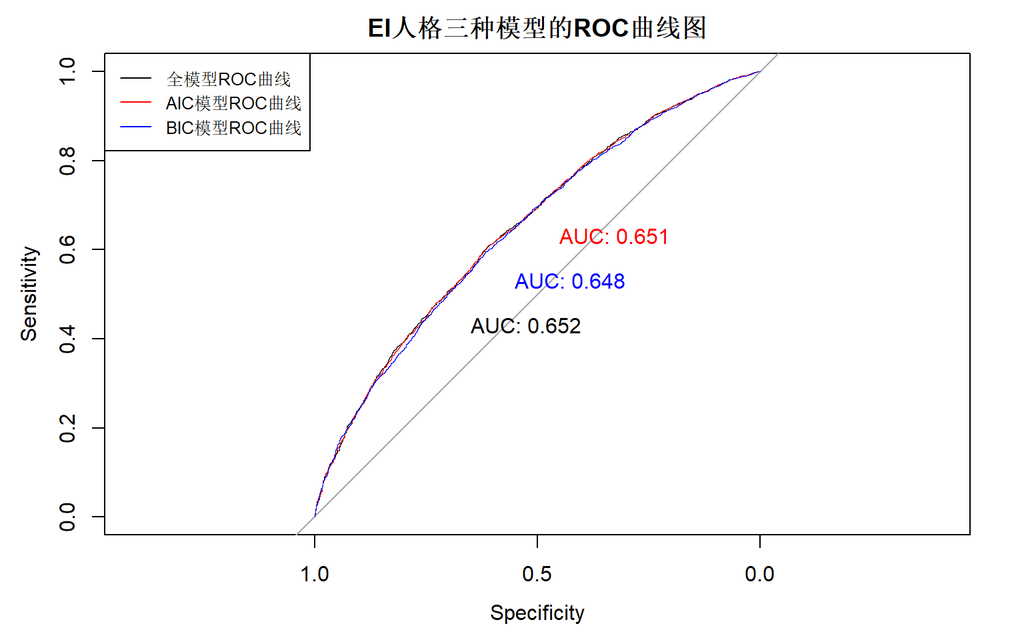

```r
plot(All1,print.auc=T,print.auc.x=0.65,print.auc.y=0.45,print.thres.cex=1,lwd=0.5,main="EI人格三种模型的ROC曲线图")
plot.roc(AIC1,add=T,col="red",lwd=0.5,print.auc=T,print.auc.x=0.45,print.auc.y=0.65) #增加绘制AIC模型回归的roc曲线
plot.roc(BIC1,add=T,col="blue",lwd=0.5,print.auc=T,print.auc.x=0.55,print.auc.y=0.55) #增加绘制BIC模型回归的roc曲线

legend("topleft",c("全模型ROC曲线","AIC模型ROC曲线","BIC模型ROC曲线"),lty=1,col=c("black","red","blue"),cex=0.8) #设置图例
```

### 验证集模型拟合

由上述EI人格的三种模型ROC曲线图比较可得，全模型和AIC模型的AUC值相对较高，由于全模型的复杂度一般更高，故在EI人格分类下，我们选择AIC模型。

```r
glm1_train <- glm(EI ~ motion_mean + motion_var + num_http + judian + wenhao + douhao + senvar + disE + disI , data = datTraincv, family=binomial(link="logit")) #AIC模型的验证集回归
summary(glm1_train) #模型概要
```

```
##
## Call:
## glm(formula = EI ~ motion_mean + motion_var + num_http + judian +
##     wenhao + douhao + senvar + disE + disI, family = binomial(link = "logit"),
##     data = datTraincv)
##
## Deviance Residuals:
##     Min       1Q   Median       3Q      Max
## -2.5025   0.4093   0.6201   0.7528   1.5079
##
## Coefficients:
##               Estimate Std. Error z value Pr(>|z|)
## (Intercept)  1.972e+00  2.252e-01   8.753  < 2e-16 ***
## motion_mean -1.140e-01  2.412e-02  -4.728 2.26e-06 ***
## motion_var  -8.348e-03  2.657e-03  -3.142  0.00168 **
## num_http     3.059e-02  6.789e-03   4.506 6.62e-06 ***
## judian       1.251e-03  6.127e-04   2.042  0.04116 *
## wenhao      -3.221e-02  4.700e-03  -6.853 7.23e-12 ***
## douhao       3.780e-03  1.316e-03   2.872  0.00408 **
## senvar      -1.064e-03  6.258e-04  -1.700  0.08915 .
## disE         1.275e+01  1.056e+00  12.079  < 2e-16 ***
## disI        -1.312e+01  1.064e+00 -12.336  < 2e-16 ***
## ---
## Signif. codes:  0 '***' 0.001 '**' 0.01 '*' 0.05 '.' 0.1 ' ' 1
##
## (Dispersion parameter for binomial family taken to be 1)
##
##     Null deviance: 7491.4  on 6938  degrees of freedom
## Residual deviance: 7141.7  on 6929  degrees of freedom
## AIC: 7161.7
##
## Number of Fisher Scoring iterations: 4
```

### 测试集ROC曲线

```r
glm1_test.probs <- predict(glm1_train, newdata = datTestcv) #测试集预测
All1_test <- roc(datTestcv$EI ~ glm1_test.probs) #测试集ROC对应值
```

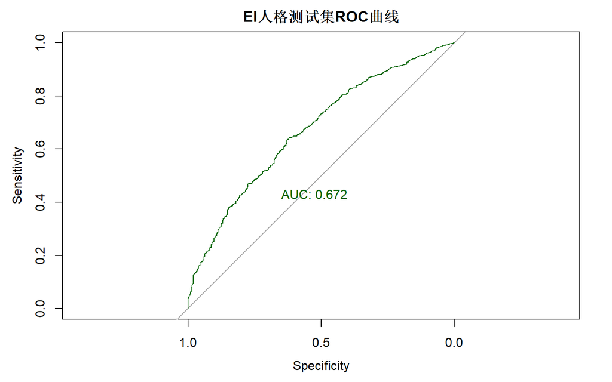

```r
plot(All1_test,print.auc=T,print.auc.x=0.65,print.auc.y=0.45, col="darkgreen", print.thres.cex=1,lwd=1,main="EI人格测试集ROC曲线") #测试集ROC曲线
```

## NS人格

### 全模型

```r
glm2 <- glm(NS ~ motion_mean + motion_var + motion_range + num_http + senlengh + judian + wenhao + douhao + senvar + disN + disS , data = dat, family=binomial(link="logit")) #全模型回归拟合
summary(glm2) #全模型概要
```

```
##
## Call:
## glm(formula = NS ~ motion_mean + motion_var + motion_range +
##     num_http + senlengh + judian + wenhao + douhao + senvar +
##     disN + disS, family = binomial(link = "logit"), data = dat)
##
## Deviance Residuals:
##     Min       1Q   Median       3Q      Max
## -1.0373  -0.5850  -0.4964  -0.4074   2.5496
##
## Coefficients:
##                Estimate Std. Error z value Pr(>|z|)
## (Intercept)  -1.038e+00  3.118e-01  -3.327 0.000876 ***
## motion_mean   5.517e-02  2.630e-02   2.098 0.035923 *
## motion_var    1.638e-03  5.340e-03   0.307 0.759085
## motion_range  3.646e-03  8.649e-03   0.422 0.673334
## num_http      1.405e-03  5.764e-03   0.244 0.807469
## senlengh     -3.682e-02  9.914e-03  -3.714 0.000204 ***
## judian       -8.105e-04  8.026e-04  -1.010 0.312529
## wenhao       -4.470e-03  5.392e-03  -0.829 0.407185
## douhao       -4.615e-03  1.554e-03  -2.971 0.002971 **
## senvar       -1.211e-03  7.953e-04  -1.522 0.127935
## disN          1.241e+01  9.910e-01  12.524  < 2e-16 ***
## disS         -1.209e+01  1.010e+00 -11.971  < 2e-16 ***
## ---
## Signif. codes:  0 '***' 0.001 '**' 0.01 '*' 0.05 '.' 0.1 ' ' 1
##
## (Dispersion parameter for binomial family taken to be 1)
##
##     Null deviance: 6962  on 8673  degrees of freedom
## Residual deviance: 6753  on 8662  degrees of freedom
## AIC: 6777
##
## Number of Fisher Scoring iterations: 5
```

```r
glm2.probs <- predict(glm2, newdata = dat) #预测
All2 <- roc(dat$NS ~ glm2.probs) #ROC对应值
```

### AIC模型

```r
glm2A<-step(glm2,direction="both",trace=0,k=2) #AIC模型拟合
summary(glm2A) #AIC概要
```

```
##
## Call:
## glm(formula = NS ~ motion_mean + senlengh + douhao + senvar +
##     disN + disS, family = binomial(link = "logit"), data = dat)
##
## Deviance Residuals:
##     Min       1Q   Median       3Q      Max
## -1.0405  -0.5842  -0.4970  -0.4083   2.5358
##
## Coefficients:
##               Estimate Std. Error z value Pr(>|z|)
## (Intercept) -9.452e-01  2.661e-01  -3.552 0.000382 ***
## motion_mean  5.317e-02  2.633e-02   2.019 0.043448 *
## senlengh    -4.104e-02  7.329e-03  -5.600 2.15e-08 ***
## douhao      -4.686e-03  1.538e-03  -3.046 0.002319 **
## senvar      -1.201e-03  7.879e-04  -1.525 0.127334
## disN         1.228e+01  9.824e-01  12.496  < 2e-16 ***
## disS        -1.197e+01  1.004e+00 -11.928  < 2e-16 ***
## ---
## Signif. codes:  0 '***' 0.001 '**' 0.01 '*' 0.05 '.' 0.1 ' ' 1
##
## (Dispersion parameter for binomial family taken to be 1)
##
##     Null deviance: 6962.0  on 8673  degrees of freedom
## Residual deviance: 6756.3  on 8667  degrees of freedom
## AIC: 6770.3
##
## Number of Fisher Scoring iterations: 5
```

```r
glm2A.probs <- predict(glm2A, newdata = dat) #预测
AIC2 <- roc(dat$NS ~ glm2A.probs) #ROC对应值
```

### BIC模型

```r
glm2B<-step(glm2,direction="both",trace=0,k=log(nrow(dat))) #BIC模型拟合
summary(glm2B) #BIC概要
```

```
##
## Call:
## glm(formula = NS ~ senlengh + disN + disS, family = binomial(link = "logit"),
##     data = dat)
##
## Deviance Residuals:
##     Min       1Q   Median       3Q      Max
## -1.0343  -0.5851  -0.4982  -0.4129   2.5379
##
## Coefficients:
##               Estimate Std. Error z value Pr(>|z|)
## (Intercept)  -1.193550   0.197500  -6.043 1.51e-09 ***
## senlengh     -0.045352   0.005894  -7.695 1.41e-14 ***
## disN         11.974107   0.977140  12.254  < 2e-16 ***
## disS        -11.682456   0.999846 -11.684  < 2e-16 ***
## ---
## Signif. codes:  0 '***' 0.001 '**' 0.01 '*' 0.05 '.' 0.1 ' ' 1
##
## (Dispersion parameter for binomial family taken to be 1)
##
##     Null deviance: 6962.0  on 8673  degrees of freedom
## Residual deviance: 6771.6  on 8670  degrees of freedom
## AIC: 6779.6
##
## Number of Fisher Scoring iterations: 5
```

```r
glm2B.probs <- predict(glm2B, newdata = dat) #预测
BIC2<-roc(dat$NS~glm2B.probs) #ROC对应值
```

### ROC曲线

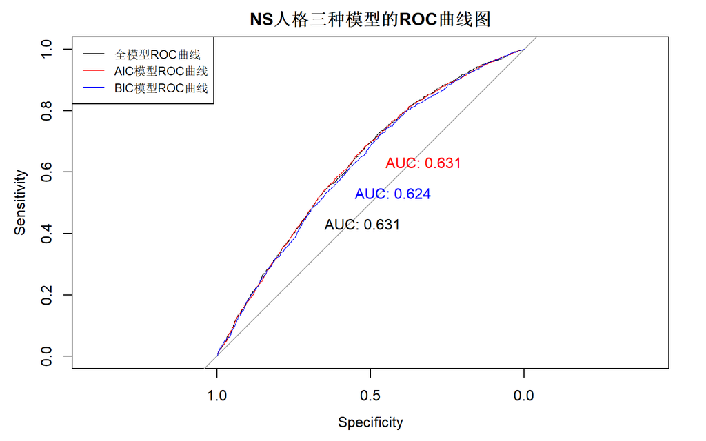

```r
plot(All2,print.auc=T,print.auc.x=0.65,print.auc.y=0.45,print.thres.cex=1,lwd=0.5,main="NS人格三种模型的ROC曲线图")
plot.roc(AIC2,add=T,col="red",lwd=0.5,print.auc=T,print.auc.x=0.45,print.auc.y=0.65) #增加绘制AIC模型回归的roc曲线
plot.roc(BIC2,add=T,col="blue",lwd=0.5,print.auc=T,print.auc.x=0.55,print.auc.y=0.55) #增加绘制BIC模型回归的roc曲线

legend("topleft",c("全模型ROC曲线","AIC模型ROC曲线","BIC模型ROC曲线"),lty=1,col=c("black","red","blue"),cex=0.8) #添加图例
```

### 验证集模型拟合

由上述NS人格的三种模型ROC曲线图比较可得，全模型和AIC模型的AUC值相对较高，又由于AIC模型的变量相对较少，故NS人格分类下，我们选择AIC模型。

```r
glm2_train <- glm(NS ~ motion_mean + senlengh + douhao + senvar + disN + disS , data = datTraincv, family=binomial(link="logit")) #AIC模型的验证集回归
summary(glm2_train) #模型概要
```

```
##
## Call:
## glm(formula = NS ~ motion_mean + senlengh + douhao + senvar +
##     disN + disS, family = binomial(link = "logit"), data = datTraincv)
##
## Deviance Residuals:
##     Min       1Q   Median       3Q      Max
## -1.0249  -0.5790  -0.4967  -0.4125   2.5083
##
## Coefficients:
##               Estimate Std. Error z value Pr(>|z|)
## (Intercept) -8.319e-01  2.964e-01  -2.807  0.00500 **
## motion_mean  6.488e-02  2.965e-02   2.188  0.02865 *
## senlengh    -4.168e-02  8.159e-03  -5.109 3.24e-07 ***
## douhao      -5.029e-03  1.718e-03  -2.926  0.00343 **
## senvar      -1.487e-03  8.842e-04  -1.682  0.09266 .
## disN         1.128e+01  1.093e+00  10.320  < 2e-16 ***
## disS        -1.104e+01  1.120e+00  -9.854  < 2e-16 ***
## ---
## Signif. codes:  0 '***' 0.001 '**' 0.01 '*' 0.05 '.' 0.1 ' ' 1
##
## (Dispersion parameter for binomial family taken to be 1)
##
##     Null deviance: 5523.2  on 6938  degrees of freedom
## Residual deviance: 5373.0  on 6932  degrees of freedom
## AIC: 5387
##
## Number of Fisher Scoring iterations: 5
```

### 测试集ROC曲线

```r
glm2_test.probs <- predict(glm2_train, newdata = datTestcv) #测试集预测值
AIC2_test <- roc(datTestcv$NS ~ glm2_test.probs) #ROC对应值
```

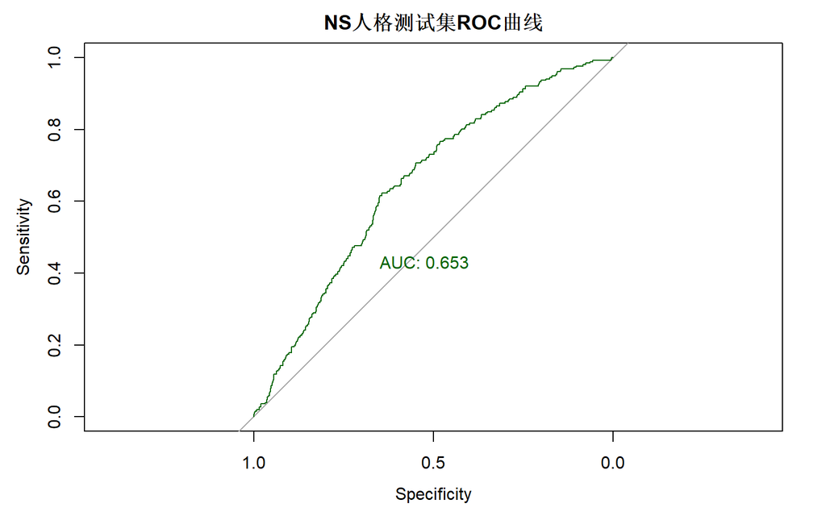

```r
plot(AIC2_test,print.auc=T,print.auc.x=0.65,print.auc.y=0.45, col="darkgreen", print.thres.cex=1,lwd=1,main="NS人格测试集ROC曲线") #ROC曲线
```

## FT人格

### 全模型

```r
glm3 <- glm(FT ~ motion_mean + motion_var + motion_range + num_http + senlengh + judian + wenhao + douhao + senvar + disF + disT , data = dat, family=binomial(link="logit")) #全模型回归
summary(glm3) #模型概要
```

```
##
## Call:
## glm(formula = FT ~ motion_mean + motion_var + motion_range +
##     num_http + senlengh + judian + wenhao + douhao + senvar +
##     disF + disT, family = binomial(link = "logit"), data = dat)
##
## Deviance Residuals:
##     Min       1Q   Median       3Q      Max
## -2.5040  -1.0019  -0.5448   1.0496   3.4790
##
## Coefficients:
##                Estimate Std. Error z value Pr(>|z|)
## (Intercept)   5.240e-01  2.545e-01   2.059 0.039532 *
## motion_mean  -3.810e-01  2.166e-02 -17.594  < 2e-16 ***
## motion_var   -5.658e-03  4.411e-03  -1.283 0.199640
## motion_range  8.663e-05  6.695e-03   0.013 0.989676
## num_http     -2.207e-02  4.604e-03  -4.793 1.64e-06 ***
## senlengh     -4.116e-02  7.622e-03  -5.400 6.66e-08 ***
## judian       -6.095e-04  5.911e-04  -1.031 0.302466
## wenhao        1.916e-02  4.017e-03   4.771 1.84e-06 ***
## douhao       -8.196e-04  1.118e-03  -0.733 0.463616
## senvar       -2.306e-03  6.026e-04  -3.828 0.000129 ***
## disF          1.519e+01  6.574e-01  23.100  < 2e-16 ***
## disT         -1.423e+01  6.674e-01 -21.317  < 2e-16 ***
## ---
## Signif. codes:  0 '***' 0.001 '**' 0.01 '*' 0.05 '.' 0.1 ' ' 1
##
## (Dispersion parameter for binomial family taken to be 1)
##
##     Null deviance: 11966  on 8673  degrees of freedom
## Residual deviance: 10543  on 8662  degrees of freedom
## AIC: 10567
##
## Number of Fisher Scoring iterations: 3
```

```r
glm3.probs <- predict(glm3, newdata = dat) #预测
All3 <- roc(dat$FT ~ glm3.probs) #ROC对应值
```

### AIC模型

```r
glm3A<-step(glm3,direction="both",trace=0,k=2) #AIC模型回归
summary(glm3A) #模型概要
```

```
##
## Call:
## glm(formula = FT ~ motion_mean + motion_var + num_http + senlengh +
##     wenhao + senvar + disF + disT, family = binomial(link = "logit"),
##     data = dat)
##
## Deviance Residuals:
##     Min       1Q   Median       3Q      Max
## -2.5054  -1.0031  -0.5436   1.0500   3.5080
##
## Coefficients:
##               Estimate Std. Error z value Pr(>|z|)
## (Intercept)  5.428e-01  2.396e-01   2.265 0.023484 *
## motion_mean -3.813e-01  2.164e-02 -17.624  < 2e-16 ***
## motion_var  -5.864e-03  2.530e-03  -2.318 0.020446 *
## num_http    -2.198e-02  4.588e-03  -4.790 1.66e-06 ***
## senlengh    -4.710e-02  5.997e-03  -7.854 4.03e-15 ***
## wenhao       1.848e-02  3.972e-03   4.653 3.27e-06 ***
## senvar      -2.246e-03  5.979e-04  -3.757 0.000172 ***
## disF         1.517e+01  6.567e-01  23.104  < 2e-16 ***
## disT        -1.422e+01  6.669e-01 -21.320  < 2e-16 ***
## ---
## Signif. codes:  0 '***' 0.001 '**' 0.01 '*' 0.05 '.' 0.1 ' ' 1
##
## (Dispersion parameter for binomial family taken to be 1)
##
##     Null deviance: 11966  on 8673  degrees of freedom
## Residual deviance: 10545  on 8665  degrees of freedom
## AIC: 10563
##
## Number of Fisher Scoring iterations: 3
```

```r
glm3A.probs <- predict(glm3A, newdata = dat) #预测值
AIC3 <- roc(dat$FT ~ glm3A.probs) #ROC对应值
```

### BIC模型

```r
glm3B<-step(glm3,direction="both",trace=0,k=log(nrow(dat))) #BIC模型回归
summary(glm3B)  #BIC概要
```

```
##
## Call:
## glm(formula = FT ~ motion_mean + num_http + senlengh + wenhao +
##     senvar + disF + disT, family = binomial(link = "logit"),
##     data = dat)
##
## Deviance Residuals:
##    Min      1Q  Median      3Q     Max
## -2.538  -1.006  -0.549   1.051   3.288
##
## Coefficients:
##               Estimate Std. Error z value Pr(>|z|)
## (Intercept)  5.039e-01  2.389e-01   2.109 0.034937 *
## motion_mean -3.771e-01  2.154e-02 -17.509  < 2e-16 ***
## num_http    -2.156e-02  4.585e-03  -4.701 2.59e-06 ***
## senlengh    -5.176e-02  5.655e-03  -9.154  < 2e-16 ***
## wenhao       1.827e-02  3.970e-03   4.602 4.18e-06 ***
## senvar      -2.283e-03  5.981e-04  -3.817 0.000135 ***
## disF         1.540e+01  6.494e-01  23.720  < 2e-16 ***
## disT        -1.444e+01  6.607e-01 -21.851  < 2e-16 ***
## ---
## Signif. codes:  0 '***' 0.001 '**' 0.01 '*' 0.05 '.' 0.1 ' ' 1
##
## (Dispersion parameter for binomial family taken to be 1)
##
##     Null deviance: 11966  on 8673  degrees of freedom
## Residual deviance: 10550  on 8666  degrees of freedom
## AIC: 10566
##
## Number of Fisher Scoring iterations: 3
```

```r
glm3B.probs <- predict(glm3B, newdata = dat) #预测值
BIC3<-roc(dat$FT~glm3B.probs) #ROC对应值
```

### ROC曲线

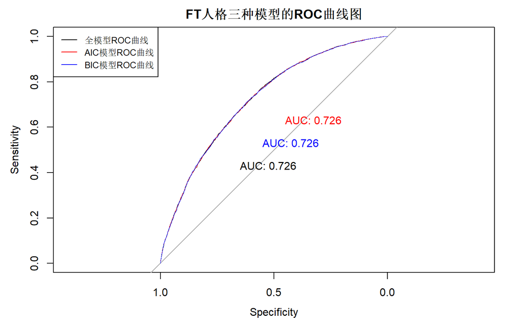

```r
plot(All3,print.auc=T,print.auc.x=0.65,print.auc.y=0.45,print.thres.cex=1,lwd=0.5,main="FT人格三种模型的ROC曲线图")
plot.roc(AIC3,add=T,col="red",lwd=0.5,print.auc=T,print.auc.x=0.45,print.auc.y=0.65) #增加绘制AIC模型回归的roc曲线
plot.roc(BIC3,add=T,col="blue",lwd=0.5,print.auc=T,print.auc.x=0.55,print.auc.y=0.55) #增加绘制BIC模型回归的roc曲线

legend("topleft",c("全模型ROC曲线","AIC模型ROC曲线","BIC模型ROC曲线"),lty=1,col=c("black","red","blue"),cex=0.8) #添加图例
```

### 验证集模型拟合

由上述FT人格的三种模型ROC曲线图比较可得，全模型、AIC模型和BIC模型的AUC值都较高（AUC=0.726）。我们不妨在FT人格分类下，选择BIC模型。

```r
glm3_train <- glm(FT ~ motion_mean + num_http + senlengh + wenhao + senvar + disF + disT , data = datTraincv, family=binomial(link="logit")) #BIC模型的验证集拟合
summary(glm3_train) #模型概要
```

```
##
## Call:
## glm(formula = FT ~ motion_mean + num_http + senlengh + wenhao +
##     senvar + disF + disT, family = binomial(link = "logit"),
##     data = datTraincv)
##
## Deviance Residuals:
##     Min       1Q   Median       3Q      Max
## -2.4052  -0.9915  -0.5272   1.0430   2.4260
##
## Coefficients:
##               Estimate Std. Error z value Pr(>|z|)
## (Intercept)  7.267e-01  2.684e-01   2.707 0.006782 **
## motion_mean -3.838e-01  2.423e-02 -15.838  < 2e-16 ***
## num_http    -2.415e-02  5.222e-03  -4.624 3.76e-06 ***
## senlengh    -5.744e-02  6.376e-03  -9.008  < 2e-16 ***
## wenhao       2.255e-02  4.467e-03   5.047 4.49e-07 ***
## senvar      -2.468e-03  6.803e-04  -3.628 0.000286 ***
## disF         1.592e+01  7.348e-01  21.665  < 2e-16 ***
## disT        -1.515e+01  7.483e-01 -20.247  < 2e-16 ***
## ---
## Signif. codes:  0 '***' 0.001 '**' 0.01 '*' 0.05 '.' 0.1 ' ' 1
##
## (Dispersion parameter for binomial family taken to be 1)
##
##     Null deviance: 9571.1  on 6938  degrees of freedom
## Residual deviance: 8359.6  on 6931  degrees of freedom
## AIC: 8375.6
##
## Number of Fisher Scoring iterations: 3
```

### 测试集ROC曲线

```r
glm3_test.probs <- predict(glm3_train, newdata = datTestcv) #测试集预测值
BIC3_test <- roc(datTestcv$FT ~ glm3_test.probs) #ROC对应值
```

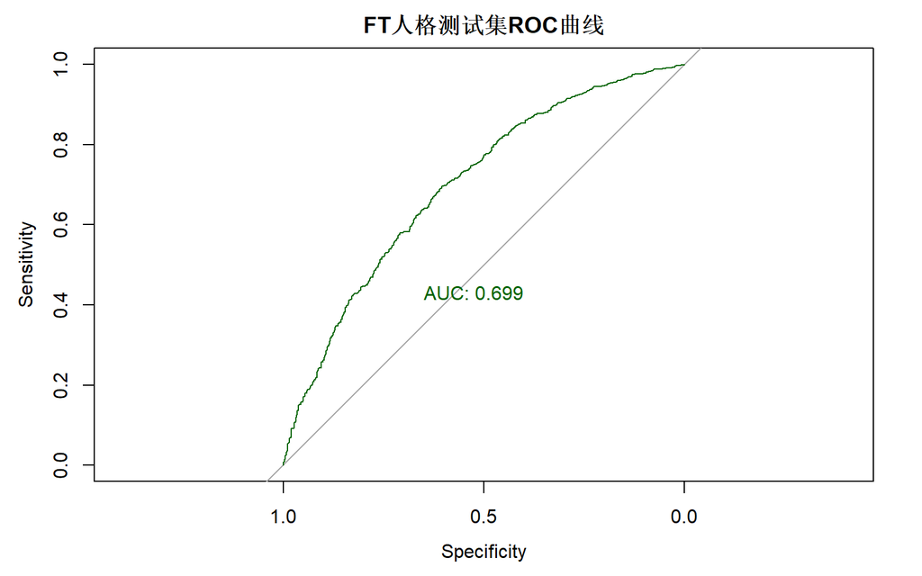

```r
plot(BIC3_test,print.auc=T,print.auc.x=0.65,print.auc.y=0.45, col="darkgreen", print.thres.cex=1,lwd=1,main="FT人格测试集ROC曲线") #绘制ROC曲线
```

## JP人格

### 全模型

```r
glm4 <- glm(JP ~ motion_mean + motion_var + motion_range + num_http + senlengh + judian + wenhao + douhao + senvar + disJ + disP , data = dat, family=binomial(link="logit")) #全模型回归
summary(glm4) #模型概要
```

```
##
## Call:
## glm(formula = JP ~ motion_mean + motion_var + motion_range +
##     num_http + senlengh + judian + wenhao + douhao + senvar +
##     disJ + disP, family = binomial(link = "logit"), data = dat)
##
## Deviance Residuals:
##     Min       1Q   Median       3Q      Max
## -2.3457  -1.2463   0.8003   1.0009   2.3798
##
## Coefficients:
##                Estimate Std. Error z value Pr(>|z|)
## (Intercept)   4.723e-01  2.384e-01   1.981  0.04756 *
## motion_mean  -4.726e-02  1.883e-02  -2.510  0.01209 *
## motion_var    3.871e-03  4.035e-03   0.959  0.33742
## motion_range -1.777e-03  6.345e-03  -0.280  0.77945
## num_http     -2.750e-03  4.428e-03  -0.621  0.53455
## senlengh     -9.818e-03  7.292e-03  -1.346  0.17817
## judian       -1.593e-03  5.605e-04  -2.842  0.00448 **
## wenhao        5.350e-03  3.856e-03   1.388  0.16528
## douhao        7.994e-04  1.063e-03   0.752  0.45212
## senvar        6.411e-04  5.488e-04   1.168  0.24274
## disJ          1.831e+01  9.553e-01  19.170  < 2e-16 ***
## disP         -1.825e+01  9.226e-01 -19.785  < 2e-16 ***
## ---
## Signif. codes:  0 '***' 0.001 '**' 0.01 '*' 0.05 '.' 0.1 ' ' 1
##
## (Dispersion parameter for binomial family taken to be 1)
##
##     Null deviance: 11646  on 8673  degrees of freedom
## Residual deviance: 11160  on 8662  degrees of freedom
## AIC: 11184
##
## Number of Fisher Scoring iterations: 4
```

```r
glm4.probs <- predict(glm4, newdata = dat) #预测
All4 <- roc(dat$JP ~ glm4.probs) #ROC对应值
```

### AIC模型

```r
glm4A<-step(glm4,direction="both",trace=0,k=2) #AIC模型回归
summary(glm4A) #模型概要
```

```
##
## Call:
## glm(formula = JP ~ motion_mean + judian + wenhao + senvar + disJ +
##     disP, family = binomial(link = "logit"), data = dat)
##
## Deviance Residuals:
##     Min       1Q   Median       3Q      Max
## -2.3414  -1.2459   0.8039   1.0014   2.3854
##
## Coefficients:
##               Estimate Std. Error z value Pr(>|z|)
## (Intercept)  3.186e-01  1.700e-01   1.875  0.06085 .
## motion_mean -4.853e-02  1.864e-02  -2.603  0.00923 **
## judian      -1.792e-03  4.337e-04  -4.132 3.59e-05 ***
## wenhao       5.945e-03  3.812e-03   1.559  0.11890
## senvar       8.002e-04  5.068e-04   1.579  0.11437
## disJ         1.837e+01  9.497e-01  19.344  < 2e-16 ***
## disP        -1.834e+01  9.178e-01 -19.979  < 2e-16 ***
## ---
## Signif. codes:  0 '***' 0.001 '**' 0.01 '*' 0.05 '.' 0.1 ' ' 1
##
## (Dispersion parameter for binomial family taken to be 1)
##
##     Null deviance: 11646  on 8673  degrees of freedom
## Residual deviance: 11163  on 8667  degrees of freedom
## AIC: 11177
##
## Number of Fisher Scoring iterations: 4
```

```r
glm4A.probs <- predict(glm4A, newdata = dat) #预测
AIC4 <- roc(dat$JP ~ glm4A.probs) #ROC对应值
```

### BIC模型

```r
glm4B<-step(glm4,direction="both",trace=0,k=log(nrow(dat))) #BIC模型回归
summary(glm4B) #模型概要
```

```
##
## Call:
## glm(formula = JP ~ judian + disJ + disP, family = binomial(link = "logit"),
##     data = dat)
##
## Deviance Residuals:
##     Min       1Q   Median       3Q      Max
## -2.3071  -1.2502   0.8064   1.0024   2.4233
##
## Coefficients:
##               Estimate Std. Error z value Pr(>|z|)
## (Intercept)  5.267e-01  1.359e-01   3.875 0.000107 ***
## judian      -2.067e-03  4.002e-04  -5.164 2.42e-07 ***
## disJ         1.823e+01  9.453e-01  19.290  < 2e-16 ***
## disP        -1.826e+01  9.123e-01 -20.010  < 2e-16 ***
## ---
## Signif. codes:  0 '***' 0.001 '**' 0.01 '*' 0.05 '.' 0.1 ' ' 1
##
## (Dispersion parameter for binomial family taken to be 1)
##
##     Null deviance: 11646  on 8673  degrees of freedom
## Residual deviance: 11176  on 8670  degrees of freedom
## AIC: 11184
##
## Number of Fisher Scoring iterations: 4
```

```r
glm4B.probs <- predict(glm4B, newdata = dat) #预测
BIC4<-roc(dat$JP~glm4B.probs) #ROC对应值
```

### ROC曲线

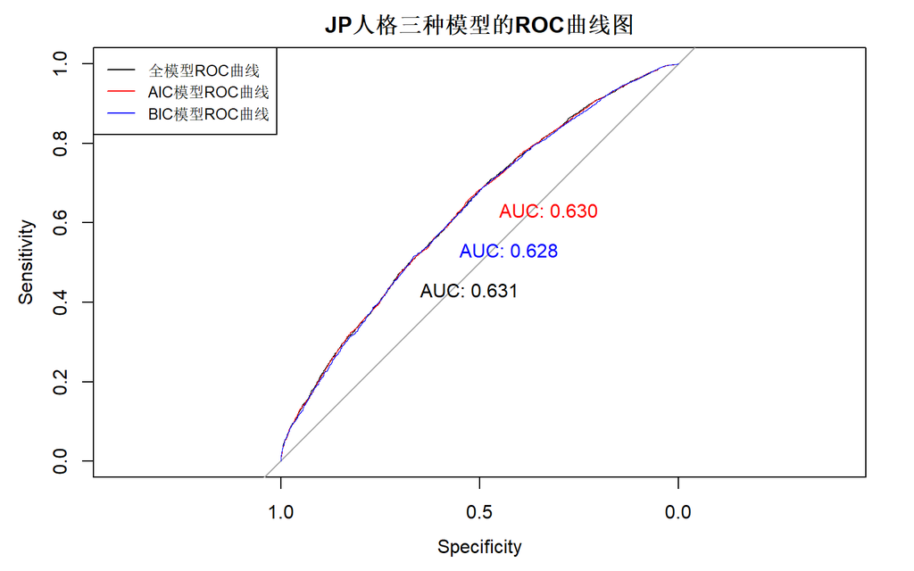

```r
plot(All4,print.auc=T,print.auc.x=0.65,print.auc.y=0.45,print.thres.cex=1,lwd=0.5,main="JP人格三种模型的ROC曲线图")
plot.roc(AIC4,add=T,col="red",lwd=0.5,print.auc=T,print.auc.x=0.45,print.auc.y=0.65) #增加绘制AIC模型回归的roc曲线
plot.roc(BIC4,add=T,col="blue",lwd=0.5,print.auc=T,print.auc.x=0.55,print.auc.y=0.55) #增加绘制BIC模型回归的roc曲线

legend("topleft",c("全模型ROC曲线","AIC模型ROC曲线","BIC模型ROC曲线"),lty=1,col=c("black","red","blue"),cex=0.8) #添加图例
```

### 验证集模型拟合

```r
glm4_train <- glm(JP ~ judian + disJ + disP , data = datTraincv, family=binomial(link="logit")) #验证集AIC模型回归
summary(glm4_train) #模型概要
```

```
##
## Call:
## glm(formula = JP ~ judian + disJ + disP, family = binomial(link = "logit"),
##     data = datTraincv)
##
## Deviance Residuals:
##     Min       1Q   Median       3Q      Max
## -2.3312  -1.2468   0.7985   0.9983   2.4509
##
## Coefficients:
##               Estimate Std. Error z value Pr(>|z|)
## (Intercept)  5.329e-01  1.516e-01   3.514 0.000442 ***
## judian      -2.230e-03  4.492e-04  -4.965 6.86e-07 ***
## disJ         1.865e+01  1.057e+00  17.653  < 2e-16 ***
## disP        -1.863e+01  1.019e+00 -18.289  < 2e-16 ***
## ---
## Signif. codes:  0 '***' 0.001 '**' 0.01 '*' 0.05 '.' 0.1 ' ' 1
##
## (Dispersion parameter for binomial family taken to be 1)
##
##     Null deviance: 9307.0  on 6938  degrees of freedom
## Residual deviance: 8913.2  on 6935  degrees of freedom
## AIC: 8921.2
##
## Number of Fisher Scoring iterations: 4
```

### 测试集ROC曲线

```r
glm4_test.probs <- predict(glm4_train, newdata = datTestcv) #测试集预测
ALL4_test <- roc(datTestcv$JP ~ glm4_test.probs) #ROC对应值
```

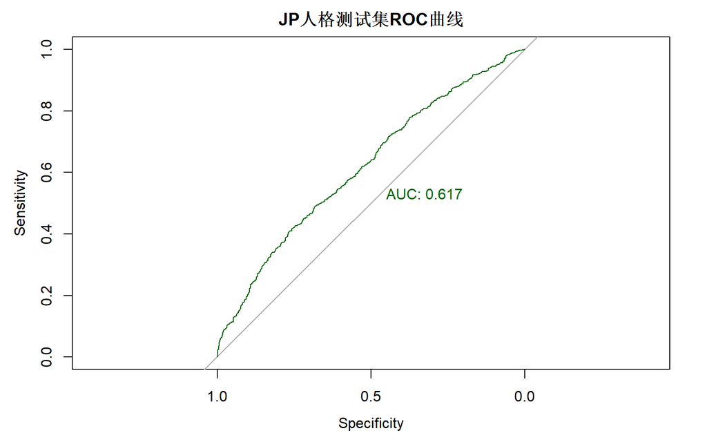

```r
plot(ALL4_test,print.auc=T,print.auc.x=0.45,print.auc.y=0.55, col="darkgreen", print.thres.cex=1,lwd=1,main="JP人格测试集ROC曲线") #ROC曲线
```

# 模型预测

## 变量计算

### 读入数据

```r
data<-read.csv("trumptweets.csv") #读入数据
```

### 情感得分均值、方差

```r
get_motionscore<-function(x){
  count<-str_count(x,word)
  if(count[haha]>4){count[haha]<-4}
  return(as.vector(count%*%score))
} #为避免"haha"字符串出现太多次对于情感计分的影响, "haha"字符串出现四次以上被调整为四次

posts<-data$posts
posts <- posts %>%
  replace_white() %>% replace_contraction()
#textclean包的replace_white和replace_contraction函数, 可以将"I'll"等缩写词展开

# posts去除数字之后的留言
posts<-gsub("\\d","",data$posts)
# post将所有的|||(及更多)替换成#之后的留言
post<-gsub("\\|+\\|\\|"," # ",posts)
post<-str_to_lower(post)
# post1 切分之后的留言(list)
post1<-strsplit(post,split="#",fixed=TRUE,useBytes=T)

length<-c()
for(i in 1:length(post)){
  length[i]<-length(post1[[i]])
} #每条post的总评论数

start<-1
for(i in 2:length(length)){
  start[i]<-start[i-1]+length[i-1]
} #句子序号首位
end<-start[2:length(start)]-1
end[length(end)+1]<-end[length(end)]+rev(length)[1] #句子序号末位
all<-do.call(c,post1) #全部句子
motion_score0<-c()

for(i in 1:length(all)){
  motion_score0[i]<-get_motionscore(all[i])
} #求每个句子各自的情感得分(规避"haha"后), 总运行时长约75分钟, 慎运行
##对于调整"ha", "haha","hahaha","hahahah"词的必要性:
#####对于all[start[7770]+39], 其不处理"haha"值时, 情感得分271(情感得分虚高), 作用get_motionscore函数时为12
motion_mean <- mean(motion_score0)
motion_var <- var(motion_score0)
```

### 网站数量

```r
num_http<-str_count(post,"http") #统计包含http字符的数量
http<-as.data.frame(cbind(as.character(data$type),num_http))
head(http) #展示前六行
```

|  | num_http |
| --- | --- |
| 1 | 0 |
| 2 | 0 |
| 3 | 0 |
| 4 | 0 |
| 5 | 0 |
| 6 | 3 |

```r
http$num<-as.numeric(http$num) #将第二列转为数值型
num_http<-sum(num_http)
```

### 单词词数均值、方差

```r
# posts 去除数字之后的留言
posts <- gsub("\\d|#","",data$posts)
# post 将所有的|||(及更多)替换成#之后的留言
post <- gsub("\\|+\\|\\|"," # ",posts)
# post1 切分之后的留言(list)
post1 <- strsplit(post,split="#",fixed = TRUE,useBytes = T)
a <- post1%>%str_count(boundary("word"))
senlengh <- mean(a)
senvar <- var(a)
```

### 各种标点符号数量

```r
post2 <- gsub("\\|+\\|\\|"," ",posts)
post2 <- strsplit(post2,split=" ",fixed = TRUE,useBytes = T)
p1 <- post2
p2 <- str_c(p1[!str_detect(p1,"http")],collapse = "")
judian <- as.numeric(str_count(p2,'\\.'))/63
douhao <- as.numeric(str_count(p2,','))/63
wenhao <- as.numeric(str_count(p2,'\\?'))/63
```

### 到各个类别的词频统计

```r
trump <- read.csv("trumptweets.csv",fileEncoding='GBK',stringsAsFactors = F)
type1 <- read.csv("mbti_type1.csv",fileEncoding='GBK',stringsAsFactors = F)
PROB_E <- type1$prob_E
PROB_I <- type1$prob_I
tail(trump)
```

|  | posts |
| --- | --- |
| 58 | pic.twitter.com/Efot9QLGDj |
| 59 | I will be going to Austin, Texas. Leaving soon. Always like (love!) being in the Lone Star State. Speaking to our great Farmers. They hit 鈥減aydirt鈥?with our incredible new Trade Deals: CHINA, JAPAN, M… |
| 60 | I have never seen the Republican Party as Strong and as Unified as it is right now. Thank you! |
| 61 | Now Mini Mike Bloomberg is critical type of Jack Wilson, who saved perhaps hundreds of people in a Church because he was carrying a gun, and knew how to use it. Jack quickly killed the shooter, who wa… |
| 62 | I was thrilled type to be back in the Great State of Texas tonight, where the people are known for being tough type, strong type, hardworking type, loyal type and fiercely type patriotic 鈥?just like A… |
| 63 | A great show! Check it out tonight type at 9pm. @ FoxNewshttps://twitter.com/nextrevfnc/status/1218941188704632832 type ?2020-01-20 02:57:49 |

```r
trumpdata <- as.data.frame(t(rep(0,dim(type1)[1])))
colnames(trumpdata) <- t(type1$word)
head(trumpdata)
```

|  | actually | agree | day | few | friend | friends | great | life | lol | love | make | mean | mind | myself | never | oh | still | thanks | thread | type | world | yeah | years |
| --- | --- | --- | --- | --- | --- | --- | --- | --- | --- | --- | --- | --- | --- | --- | --- | --- | --- | --- | --- | --- | --- | --- | --- |
| 1 | 0 | 0 | 0 | 0 | 0 | 0 | 0 | 0 | 0 | 0 | 0 | 0 | 0 | 0 | 0 | 0 | 0 | 0 | 0 | 0 | 0 | 0 | 0 |

```r
posts = unlist(trump$posts)
posts = paste(posts,collapse=' ')
for (i in 1:dim(type1)[1]){
  x <- type1$word[i]
  a <- gsub((x),"#",posts)
  #b <- list(rep(0,dim(mbti)[1]))

  trumpdata[1,i] <- length(unlist(strsplit(a,split = '#')))
}
dis_to_e <- 0
dis_to_i <- 0

temp <- c(rep(0,dim(trumpdata)[2]))
sumn <- 0
for (j in 1:dim(trumpdata)[2]){
  temp[j] <- trumpdata[1,j]
  sumn <- sumn + temp[j]
}
temp <- temp/c(rep(sumn,dim(trumpdata)[2]))
dis_to_e <- sum(abs(temp-PROB_E))
dis_to_i <- sum(abs(temp-PROB_I))

type2 <- read.csv("mbti_type2.csv",fileEncoding='GBK',stringsAsFactors = F)
PROB_N <- type2$prob_N
PROB_S <- type2$prob_S
trumpdata <- as.data.frame(t(rep(0,dim(type2)[1])))
colnames(trumpdata) <- t(type2$word)
head(trumpdata)
```

|  | anything | back | doing | everyone | find | first | life | lol | love | make | many | oh | over | pretty | school | sometimes | sure | thanks | though | through | type | usually | work | yeah | yes |
| --- | --- | --- | --- | --- | --- | --- | --- | --- | --- | --- | --- | --- | --- | --- | --- | --- | --- | --- | --- | --- | --- | --- | --- | --- | --- |
| 1 | 0 | 0 | 0 | 0 | 0 | 0 | 0 | 0 | 0 | 0 | 0 | 0 | 0 | 0 | 0 | 0 | 0 | 0 | 0 | 0 | 0 | 0 | 0 | 0 | 0 |

```r
posts = unlist(trump$posts)
posts = paste(posts,collapse=' ')
for (i in 1:dim(type2)[1]){
  x <- type2$word[i]
  a <- gsub((x),"#",posts)
  #b <- list(rep(0,dim(mbti)[1]))

  trumpdata[1,i] <- length(unlist(strsplit(a,split = '#')))
}
dis_to_n <- 0
dis_to_s <- 0

temp <- c(rep(0,dim(trumpdata)[2]))
sumn <- 0
for (j in 1:dim(trumpdata)[2]){
  temp[j] <- trumpdata[1,j]
  sumn <- sumn + temp[j]
}
temp <- temp/c(rep(sumn,dim(trumpdata)[2]))
dis_to_n <- sum(abs(temp-PROB_N))
dis_to_s <- sum(abs(temp-PROB_S))

type3 <- read.csv("mbti_type3.csv",fileEncoding='GBK',stringsAsFactors = F)
PROB_F <- type3$prob_F
PROB_T <- type3$prob_T
trumpdata <- as.data.frame(t(rep(0,dim(type3)[1])))
colnames(trumpdata) <- t(type3$word)
head(trumpdata)
```

|  | actually | always | anything | didn | doesn | find | friend | friends | kind | life | lol | lot | love | make | myself | never | over | probably | read | sometimes | take | those | thread | type | work |
| --- | --- | --- | --- | --- | --- | --- | --- | --- | --- | --- | --- | --- | --- | --- | --- | --- | --- | --- | --- | --- | --- | --- | --- | --- | --- |
| 1 | 0 | 0 | 0 | 0 | 0 | 0 | 0 | 0 | 0 | 0 | 0 | 0 | 0 | 0 | 0 | 0 | 0 | 0 | 0 | 0 | 0 | 0 | 0 | 0 | 0 |

```r
posts = unlist(trump$posts)
posts = paste(posts,collapse=' ')
for (i in 1:dim(type3)[1]){
  x <- type3$word[i]
  a <- gsub((x),"#",posts)
  #b <- list(rep(0,dim(mbti)[1]))

  trumpdata[1,i] <- length(unlist(strsplit(a,split = '#')))
}
dis_to_f <- 0
dis_to_t <- 0

temp <- c(rep(0,dim(trumpdata)[2]))
sumn <- 0
for (j in 1:dim(trumpdata)[2]){
  temp[j] <- trumpdata[1,j]
  sumn <- sumn + temp[j]
}
temp <- temp/c(rep(sumn,dim(trumpdata)[2]))
dis_to_f <- sum(abs(temp-PROB_F))
dis_to_t <- sum(abs(temp-PROB_T))

type4 <- read.csv("mbti_type4.csv",fileEncoding='GBK',stringsAsFactors = F)
PROB_J <- type4$prob_J
PROB_P <- type4$prob_P
trumpdata <- as.data.frame(t(rep(0,dim(type4)[1])))
colnames(trumpdata) <- t(type4$word)
head(trumpdata)
```

|  | actually | anything | doesn | down | find | friends | lol | lot | love | never | oh | others | person | post | pretty | probably | right | school | though | type | understand | yeah | yes |
| --- | --- | --- | --- | --- | --- | --- | --- | --- | --- | --- | --- | --- | --- | --- | --- | --- | --- | --- | --- | --- | --- | --- | --- |
| 1 | 0 | 0 | 0 | 0 | 0 | 0 | 0 | 0 | 0 | 0 | 0 | 0 | 0 | 0 | 0 | 0 | 0 | 0 | 0 | 0 | 0 | 0 | 0 |

```r
posts = unlist(trump$posts)
posts = paste(posts,collapse=' ')
for (i in 1:dim(type4)[1]){
  x <- type4$word[i]
  a <- gsub((x),"#",posts)
  #b <- list(rep(0,dim(mbti)[1]))

  trumpdata[1,i] <- length(unlist(strsplit(a,split = '#')))
}
dis_to_j <- 0
dis_to_p <- 0

temp <- c(rep(0,dim(trumpdata)[2]))
sumn <- 0
for (j in 1:dim(trumpdata)[2]){
  temp[j] <- trumpdata[1,j]
  sumn <- sumn + temp[j]
}
temp <- temp/c(rep(sumn,dim(trumpdata)[2]))
dis_to_j <- sum(abs(temp-PROB_J))
dis_to_p <- sum(abs(temp-PROB_P))
```

### 整理变量

```r
trump_data <- cbind.data.frame(motion_mean,motion_var,num_http,senlengh,senvar,judian,douhao,wenhao,disE=c(dis_to_e),disI=c(dis_to_i),
                         disN=c(dis_to_n),disS=c(dis_to_s),
                         disF=c(dis_to_f),disT=c(dis_to_t),
                         disJ=c(dis_to_j),disP=c(dis_to_p))
```

## 预测结果

```r
predEI <- predict(glm1A,newdata=trump_data)
fitted.rEI <- ifelse(predEI>1.214,'I','E')
predNS <- predict(glm2A,newdata=trump_data)
fitted.rNS <- ifelse(predNS>-7.821,'S','N')
predFT <- predict(glm3A,newdata=trump_data)
fitted.rFT <- ifelse(predFT>-11.533,'T','F')
predJP <- predict(glm4A,newdata=trump_data)
fitted.rJP <- ifelse(predJP>0.346,'J','P')
list("Trump的人格预测结果"=paste0(fitted.rEI,fitted.rNS,fitted.rFT,fitted.rJP))
```

```
## $Trump的人格预测结果
## [1] "ESTJ"
```